# Clear Creek

Sadie Gill, Mark Tompkins

July 1, 2019

## Floodplain Modeling Details

**Data Source:**

[Scaled USFWS / FEMA 1D HEC-RAS hydraulic model](https://s3-us-west-2.amazonaws.com/cvpiahabitat-r-package/cvpia-sit-model-inputs/CVPIA+Annual+Progress+Report+Fiscal+Year+2017.pdf)

### Fall Run

No site-specific hydraulic modeling was available for this watershed. A flow to floodplain area relationship was generated for this watershed by scaling the flow to floodplain area relationship for Cottonwood Creek based on hydrologic and geomorphic analyses. Flows and corresponding floodplain areas per unit length were calculated for this watershed as 21% of Cottonwood Creek values based on the ratio of mean flow from December to June between this watershed and Cottonwood Creek. Of the entire mapped 8 mile rearing extent in this watershed, 8 miles were classified as low gradient and 0 miles were classified as high gradient based on a geomorphic analysis. A scaling factor of 0.1 was applied to the area per unit length for the high gradient extent. No scaling factor was applied to the low gradient extent.

### Spring Run and Steelhead

No site-specific hydraulic modeling was available for this watershed. A flow to floodplain area relationship was generated for this watershed by scaling the flow to floodplain area relationship for Cottonwood Creek based on hydrologic and geomorphic analyses. Flows and corresponding floodplain areas per unit length were calculated for this watershed as 21% of Cottonwood Creek values based on the ratio of mean flow from December to June between this watershed and Cottonwood Creek. Of the entire mapped 17.9 mile rearing extent in this watershed, 8 miles were classified as low gradient and 9.9 miles were classified as high gradient based on a geomorphic analysis. A scaling factor of 0.1 was applied to the area per unit length for the high gradient extent. No scaling factor was applied to the low gradient extent.

## Floodplain Data

| flow_cfs | FR_floodplain_acres | SR_floodplain_acres | ST_floodplain_acres | watershed |
| --- | --- | --- | --- | --- |
| 1590.201 | 0.0000000 | 0.0000000 | 0.0000000 | Clear Creek |
| 1665.526 | 0.4424499 | 0.4973432 | 0.4973432 | Clear Creek |
| 1740.852 | 0.9927313 | 1.1158963 | 1.1158963 | Clear Creek |
| 1816.177 | 1.4421274 | 1.6210475 | 1.6210475 | Clear Creek |
| 1891.502 | 1.8118601 | 2.0366519 | 2.0366519 | Clear Creek |

*…with 5 more rows*

## Floodplain Plot

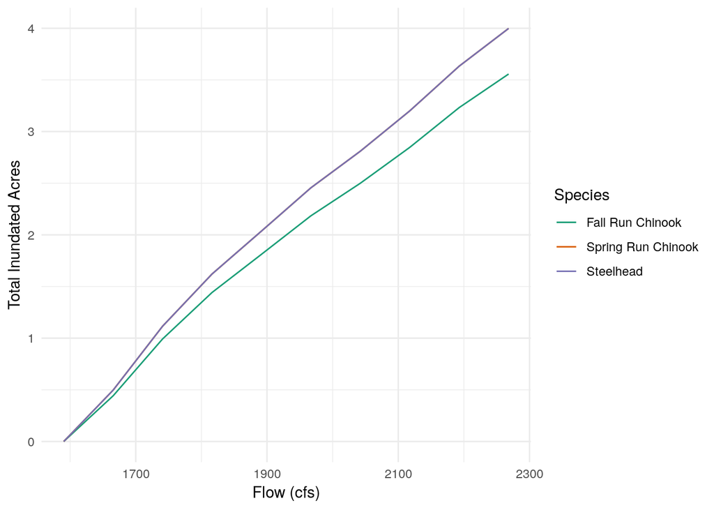